# Peer Assessment 1

## Loading and preprocessing the data

### 1. Load the data

```r
library(data.table)
data <- fread("activity.csv", header = TRUE, stringsAsFactors = FALSE, na.strings = "NA")
data$date <- as.Date(data$date, format="%Y-%m-%d")
data$interval <- as.numeric(data$interval)
```

### 2. Remove NAs value for steps and transform date column to date value

```r
data_no_mising_values <- data[!is.na(data$steps),]
```

# What is mean total number of steps taken per day?

### 1. Make a histogram of the total number of steps taken each day

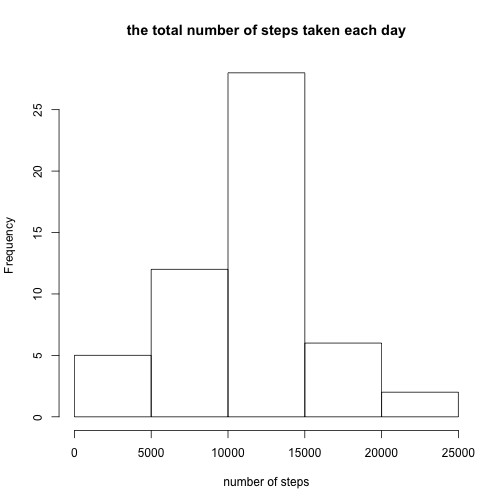

```r
library(plyr)
total_num_steps_per_day <- ddply(data_no_mising_values, ~date, summarise, sum=sum(steps))
hist(total_num_steps_per_day$sum, main = 'the total number of steps taken each day', xlab='number of steps')
```

```r
library(plyr)
report <- ddply(data_no_mising_values,~date,summarise, mean_num_steps=mean(steps), median_num_steps=median(steps))
library(xtable)
xt <- xtable(report)
print(xt, type ="html")
```

|  | date | mean_num_steps | median_num_steps |
| --- | --- | --- | --- |
| 1 | 15615.00 | 0.44 | 0.00 |
| 2 | 15616.00 | 39.42 | 0.00 |
| 3 | 15617.00 | 42.07 | 0.00 |
| 4 | 15618.00 | 46.16 | 0.00 |
| 5 | 15619.00 | 53.54 | 0.00 |
| 6 | 15620.00 | 38.25 | 0.00 |
| 7 | 15622.00 | 44.48 | 0.00 |
| 8 | 15623.00 | 34.38 | 0.00 |
| 9 | 15624.00 | 35.78 | 0.00 |
| 10 | 15625.00 | 60.35 | 0.00 |
| 11 | 15626.00 | 43.15 | 0.00 |
| 12 | 15627.00 | 52.42 | 0.00 |
| 13 | 15628.00 | 35.20 | 0.00 |
| 14 | 15629.00 | 52.38 | 0.00 |
| 15 | 15630.00 | 46.71 | 0.00 |
| 16 | 15631.00 | 34.92 | 0.00 |
| 17 | 15632.00 | 41.07 | 0.00 |
| 18 | 15633.00 | 36.09 | 0.00 |
| 19 | 15634.00 | 30.63 | 0.00 |
| 20 | 15635.00 | 46.74 | 0.00 |
| 21 | 15636.00 | 30.97 | 0.00 |
| 22 | 15637.00 | 29.01 | 0.00 |
| 23 | 15638.00 | 8.65 | 0.00 |
| 24 | 15639.00 | 23.53 | 0.00 |
| 25 | 15640.00 | 35.14 | 0.00 |
| 26 | 15641.00 | 39.78 | 0.00 |
| 27 | 15642.00 | 17.42 | 0.00 |
| 28 | 15643.00 | 34.09 | 0.00 |
| 29 | 15644.00 | 53.52 | 0.00 |
| 30 | 15646.00 | 36.81 | 0.00 |
| 31 | 15647.00 | 36.70 | 0.00 |
| 32 | 15649.00 | 36.25 | 0.00 |
| 33 | 15650.00 | 28.94 | 0.00 |
| 34 | 15651.00 | 44.73 | 0.00 |
| 35 | 15652.00 | 11.18 | 0.00 |
| 36 | 15655.00 | 43.78 | 0.00 |
| 37 | 15656.00 | 37.38 | 0.00 |
| 38 | 15657.00 | 25.47 | 0.00 |
| 39 | 15659.00 | 0.14 | 0.00 |
| 40 | 15660.00 | 18.89 | 0.00 |
| 41 | 15661.00 | 49.79 | 0.00 |
| 42 | 15662.00 | 52.47 | 0.00 |
| 43 | 15663.00 | 30.70 | 0.00 |
| 44 | 15664.00 | 15.53 | 0.00 |
| 45 | 15665.00 | 44.40 | 0.00 |
| 46 | 15666.00 | 70.93 | 0.00 |
| 47 | 15667.00 | 73.59 | 0.00 |
| 48 | 15668.00 | 50.27 | 0.00 |
| 49 | 15669.00 | 41.09 | 0.00 |
| 50 | 15670.00 | 38.76 | 0.00 |
| 51 | 15671.00 | 47.38 | 0.00 |
| 52 | 15672.00 | 35.36 | 0.00 |
| 53 | 15673.00 | 24.47 | 0.00 |

## What is the average daily activity pattern?

### 1. Make a time series plot (i.e. type = “l”) of the 5-minute interval (x-axis) and the average number of steps taken, averaged across all days (y-axis)

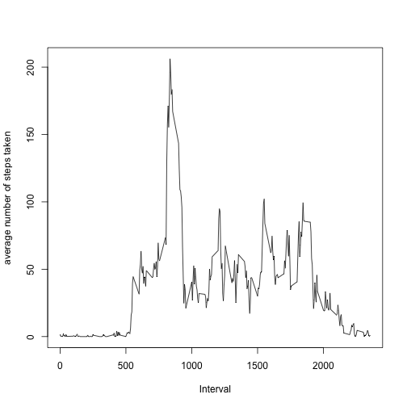

```r
mean_num_steps_per_interval <- ddply(data_no_mising_values,~interval,summarise, mean_steps=mean(steps))
plot(mean_num_steps_per_interval$interval, mean_num_steps_per_interval$mean_steps, ylab = "average number of steps taken", xlab = "Interval", type = "l")
```

### 2. Which 5-minute interval, on average across all the days in the dataset, contains the maximum number of steps?

```r
max_step <- max(mean_num_steps_per_interval$mean_steps)
theInterval <- mean_num_steps_per_interval[mean_num_steps_per_interval$mean_steps == max_step, 1]
```

The 5-minute interval is 835

## Imputing missing values

### 1. Calculate and report the total number of missing values in the dataset (i.e. the total number of rows with NAs)

```r
total_number_of_missing_values <- nrow(data) - nrow(data_no_mising_values)
```

Number of missing values is 2304

### 2. Devise a strategy for filling in all of the missing values in the dataset. The strategy does not need to be sophisticated. For example, you could use the mean/median for that day, or the mean for that 5-minute interval, etc.

Using mean_num_steps_per_interval to get the average number of steps to replace NA data

### 3. Create a new dataset that is equal to the original dataset but with the missing data filled in.

```r
data_fill_in_missing_values <- data
data_fill_in_missing_values$steps <- mapply(function(steps, interval)
                                                    if (is.na(steps))
                                                        mean_num_steps_per_interval[mean_num_steps_per_interval$interval == interval, 2]
                                                    else
                                                        steps, data_fill_in_missing_values$steps, data_fill_in_missing_values$interval)
```

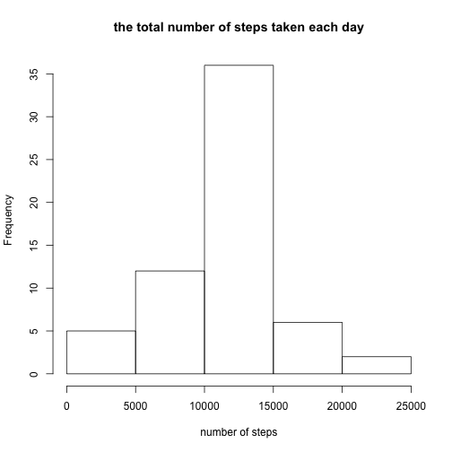

```r
library(plyr)

total_num_steps_per_day <- ddply(data_fill_in_missing_values,~date,summarise, sum=sum(steps))
hist(total_num_steps_per_day$sum, main = 'the total number of steps taken each day', xlab='number of steps')
```

```r
report <- ddply(data_fill_in_missing_values,~date,summarise, mean_num_steps=mean(steps), median_num_steps=median(steps))
library(xtable)
xt <- xtable(report)
print(xt, type ="html")
```

|  | date | mean_num_steps | median_num_steps |
| --- | --- | --- | --- |
| 1 | 15614.00 | 37.38 | 34.11 |
| 2 | 15615.00 | 0.44 | 0.00 |
| 3 | 15616.00 | 39.42 | 0.00 |
| 4 | 15617.00 | 42.07 | 0.00 |
| 5 | 15618.00 | 46.16 | 0.00 |
| 6 | 15619.00 | 53.54 | 0.00 |
| 7 | 15620.00 | 38.25 | 0.00 |
| 8 | 15621.00 | 37.38 | 34.11 |
| 9 | 15622.00 | 44.48 | 0.00 |
| 10 | 15623.00 | 34.38 | 0.00 |
| 11 | 15624.00 | 35.78 | 0.00 |
| 12 | 15625.00 | 60.35 | 0.00 |
| 13 | 15626.00 | 43.15 | 0.00 |
| 14 | 15627.00 | 52.42 | 0.00 |
| 15 | 15628.00 | 35.20 | 0.00 |
| 16 | 15629.00 | 52.38 | 0.00 |
| 17 | 15630.00 | 46.71 | 0.00 |
| 18 | 15631.00 | 34.92 | 0.00 |
| 19 | 15632.00 | 41.07 | 0.00 |
| 20 | 15633.00 | 36.09 | 0.00 |
| 21 | 15634.00 | 30.63 | 0.00 |
| 22 | 15635.00 | 46.74 | 0.00 |
| 23 | 15636.00 | 30.97 | 0.00 |
| 24 | 15637.00 | 29.01 | 0.00 |
| 25 | 15638.00 | 8.65 | 0.00 |
| 26 | 15639.00 | 23.53 | 0.00 |
| 27 | 15640.00 | 35.14 | 0.00 |
| 28 | 15641.00 | 39.78 | 0.00 |
| 29 | 15642.00 | 17.42 | 0.00 |
| 30 | 15643.00 | 34.09 | 0.00 |
| 31 | 15644.00 | 53.52 | 0.00 |
| 32 | 15645.00 | 37.38 | 34.11 |
| 33 | 15646.00 | 36.81 | 0.00 |
| 34 | 15647.00 | 36.70 | 0.00 |
| 35 | 15648.00 | 37.38 | 34.11 |
| 36 | 15649.00 | 36.25 | 0.00 |
| 37 | 15650.00 | 28.94 | 0.00 |
| 38 | 15651.00 | 44.73 | 0.00 |
| 39 | 15652.00 | 11.18 | 0.00 |
| 40 | 15653.00 | 37.38 | 34.11 |
| 41 | 15654.00 | 37.38 | 34.11 |
| 42 | 15655.00 | 43.78 | 0.00 |
| 43 | 15656.00 | 37.38 | 0.00 |
| 44 | 15657.00 | 25.47 | 0.00 |
| 45 | 15658.00 | 37.38 | 34.11 |
| 46 | 15659.00 | 0.14 | 0.00 |
| 47 | 15660.00 | 18.89 | 0.00 |
| 48 | 15661.00 | 49.79 | 0.00 |
| 49 | 15662.00 | 52.47 | 0.00 |
| 50 | 15663.00 | 30.70 | 0.00 |
| 51 | 15664.00 | 15.53 | 0.00 |
| 52 | 15665.00 | 44.40 | 0.00 |
| 53 | 15666.00 | 70.93 | 0.00 |
| 54 | 15667.00 | 73.59 | 0.00 |
| 55 | 15668.00 | 50.27 | 0.00 |
| 56 | 15669.00 | 41.09 | 0.00 |
| 57 | 15670.00 | 38.76 | 0.00 |
| 58 | 15671.00 | 47.38 | 0.00 |
| 59 | 15672.00 | 35.36 | 0.00 |
| 60 | 15673.00 | 24.47 | 0.00 |
| 61 | 15674.00 | 37.38 | 34.11 |

## Are there differences in activity patterns between weekdays and weekends?

### 1. Create a new factor variable in the dataset with two levels – “weekday” and “weekend” indicating whether a given date is a weekday or weekend day.

```r
data_fill_in_missing_values$wday <- as.factor(ifelse(weekdays( data_fill_in_missing_values$date) %in% c("Saturday","Sunday"), "Weekend", "Weekday"))
```

### 2. Make a panel plot containing a time series plot (i.e. type = “l”) of the 5-minute interval (x-axis) and the average number of steps taken, averaged across all weekday days or weekend days (y-axis).

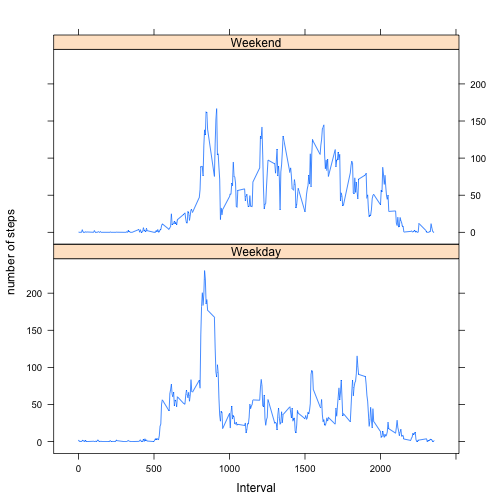

```r
library(lattice)
total_num_steps_per_wday <- ddply(data_fill_in_missing_values,.(interval, wday),summarise, mean_steps=mean(steps))
xyplot(mean_steps ~ interval |
          wday, data = total_num_steps_per_wday,
       layout = c(1, 2), ylab = "number of steps", xlab = "Interval", type = 'l')
```